# Week 1: Our Approach to Modelling Data

## [Peter Hurley](http://www.sussex.ac.uk/profiles/188689) and [Phil Rooney](http://www.sussex.ac.uk/profiles/252374)

### Astronomy Centre, Maths and Physical Sciences

### People from different fields will have different levels of:

- expertise
- terminology
- philosophy

### to Machine Learning and Data Analysis.

## As Astronomers, we don't get to repeat expermients..

### We can only observe!

### Observing is expensive!

[figure not shown]

## Bayesian Probability

P( A | B ) = ( P( B | A ) * P(A))/P(B)

posterior = (likelihood*prior)/marginal_likelihood

### Medical Example

Blood test detects vampirism 95% of the time.

It makes mistakes 1% of the time

Suppose vampires Make up 0.1% of the population

What is the probability that a positive case is a vampire?

P(vampire | positive) = (P( positive | vampire )*P(vampire))/P(positive)

## Probabilistic Programming

> ["Define probability models and then “solve” these models automatically"](http://radar.oreilly.com/2013/04/probabilistic-programming.html)

### Analogy: Computer programming!

> High level languages frees developer from complexities of processor and memory architecture, e.g. Python, Matlab

> Probabilitic Programming languages free developers from complexities of high-performance probabilistic inference (e.g. MCMC, EM, Variational Bayes)

[figure not shown]

### Probabilisitic Programming Languages:

Some examples..

1. [PyMC](https://github.com/pymc-devs/pymc) python module that implements a suite of MCMC algorithms as python classes, is extremely flexible and applicable to a large suite of problems. PyMC includes methods for summarizing output, plotting, goodness-of-fit and convergence diagnostics.
2. [Infer.NET](http://research.microsoft.com/en-us/um/cambridge/projects/infernet/) is a software library developed by Microsoft for expressing graphical models and implementing Bayesian inference using a variety of algorithms.
3. [Venture](http://probcomp.csail.mit.edu/venture/) is an interactive, Turing-complete, higher-order probabilistic programming platform that aims to be sufficiently expressive, extensible and efficient for general-purpose use. Its virtual machine supports multiple scalable, reprogrammable inference strategies, plus two front-end languages: VenChurch and VentureScript.
4. [Stan](http://mc-stan.org/) exposes a language for defining probability density functions for probabilistic models. Stan includes a compiler, which produces C++ code that performs Bayesian inference via a method similar to Hamiltonian Monte Carlo sampling.

## Why is this Important?

- Allows us to separate out *modelling* and *inference*
- Can create more flexible, and complex models
- Can deal with more complex data
- No longer have to rely on *Blackbox* like approaches

### Probabilisitic Programming Languages:

Some examples..

1. [PyMC](https://github.com/pymc-devs/pymc) python module that implements a suite of MCMC algorithms as python classes, is extremely flexible and applicable to a large suite of problems. PyMC includes methods for summarizing output, plotting, goodness-of-fit and convergence diagnostics.
2. [Infer.NET](http://research.microsoft.com/en-us/um/cambridge/projects/infernet/) is a software library developed by Microsoft for expressing graphical models and implementing Bayesian inference using a variety of algorithms.
3. [Venture](http://probcomp.csail.mit.edu/venture/) is an interactive, Turing-complete, higher-order probabilistic programming platform that aims to be sufficiently expressive, extensible and efficient for general-purpose use. Its virtual machine supports multiple scalable, reprogrammable inference strategies, plus two front-end languages: VenChurch and VentureScript.
4. [Stan](http://mc-stan.org/) exposes a language for defining probability density functions for probabilistic models. Stan includes a compiler, which produces C++ code that performs Bayesian inference via a method similar to Hamiltonian Monte Carlo sampling.

## [Cluster failure: Why fMRI inferences for spatial extent have inflated false-positive rates](http://www.pnas.org/content/113/28/7900.full)

### Anders Eklunda, Thomas E. Nicholsd, and Hans Knutssona

1. People typically use software like SPM, FSL, AFNI for fMRI analysis
2. Gaussian Random Field Theory used to decide whether clusters of voxels are significantly activated
3. Assumption about specific correlation function for voxels often inappropriate for different regions of the brain

## Building probabilitic models

The key to building probabilisitic models is to model dependencies as structure!

> One morning Tracey leaves her house and realises that her grass is wet. Is it due to overnight rain or did she forget to turn off the sprinkler last night? Next she notices that the grass of her neighbour, Jack, is also wet. This explains away to some extent the possibility that her sprinkler was left on, and she concludes therefore that it has probably been raining.
- $R \in {0, 1}$, $R = 1$ means that it has been raining, and 0 otherwise
- $S \in {0, 1}$, $S = 1$ means that Tracey has forgotten to turn off the sprinkler, 0 otherwise
- $J \in {0, 1}$, $J = 1$ means that Jack’s grass is wet, and 0 otherwise
- $T \in {0, 1}$, $T = 1$ means that Tracey’s Grass is wet, and 0 otherwise

We want to model $p(T,J,R,S)$, i.e. Tracy's world. Naïvely that requires $2^4=16$ states e.g. $p(T = 1,J = 0,R = 0,S = 1) = 0.057$ etc.

### However, we can use our prior knowledge to help constrain the model

- $p(T |J, R, S) = p(T |R, S)$
  - The probability that Tracey's grass is wet only depends on whether it has been raining or the sprinkler
- $p(J|R, S) = p(J|R)$
  - The probability that Jack's grass is wet only depends on whether it has been raining
- $p(R|S) = p(R)$
  - The probabiity it has been raining does not depend on the sprinkler

### Combining all of this conditional independence information...

- $p(T,J,R,S) = p(T|R,S)p(J|R)p(R)p(S)$

There is a far more intuitive way to visualise these conditional dependecies using..

## Probabilistic Graphical Models

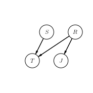

```python
from matplotlib import rc
%matplotlib inline
rc("font", family="serif", size=12)
rc("text", usetex=True)
import daft

#Set up plot space
pgm = daft.PGM([3, 3], origin=[0, 0])

#Add nodes
pgm.add_node(daft.Node("T", r"$T$", 1,1))
pgm.add_node(daft.Node("J", r"$J$", 2,1))
pgm.add_node(daft.Node("R", r"$R$", 2.5,2))
pgm.add_node(daft.Node("S", r"$S$", 1.5,2))

pgm.add_edge("R", "T")
pgm.add_edge("R", "J")
pgm.add_edge("S", "T")
pgm.render()
```

### No single agreed notation but:

Always:

- Nodes represent variables and graph structure represent dependencies

Almost Always:

- Plates indicate replication

Optional Distinctions:

- Continuous vs Discrete
- Observed vs Hidden
- Stocastic vs Deterministic
- Observed Variables vs Known Property of Experimental Design

### Binary process

# Examples

> [Thousands of users rely on Stan for statistical modeling, data analysis, and prediction in the social, biological, and physical sciences, engineering, and business.](http://mc-stan.org/)

Users specify log density functions in Stan’s probabilistic programming language and get:

- full Bayesian statistical inference with MCMC sampling (NUTS, HMC)
- approximate Bayesian inference with variational inference (ADVI)
- penalized maximum likelihood estimation with optimization (L-BFGS)

Stan’s math library provides differentiable probability functions & linear algebra (C++ autodiff). Additional R packages provide expression-based linear modeling, posterior visualization, and leave-one-out cross-validation.

## Single Variable

```python
import pystan
import numpy as np
import seaborn as sns
from astropy.table import Table
%matplotlib inline


one_vat_model = """

// Inferring a Rate
data {
  int<lower=1> n;
  int<lower=0> k;
}
parameters {
  real<lower=0,upper=1> theta;
}
model {
  // Prior Distribution for Rate Theta
  theta ~ beta(1, 1);

  // Observed Counts
  k ~ binomial(n, theta);
}
"""

k = 10
n = 20

input_data = {'k':10, 'n':20}

samples = pystan.stan(model_code=one_vat_model, data=input_data, iter=10000, chains=2
)
```